# Illustrating the hazard function

Steve Simon

Friday, July 15, 2016

## Abstract

When you have data measuring the time to an event, you can examine the relationship between various predictor variables and the time to the event using a Cox proportional hazards model. In this talk, you will see what a hazard function is and describe the interpretations of increasing, decreasing, and constant hazard. Then you will examine the log rank test, a simple test closely tied to the Kaplan-Meier curve, and the Cox proportional hazards model.

## What is the hazard function?

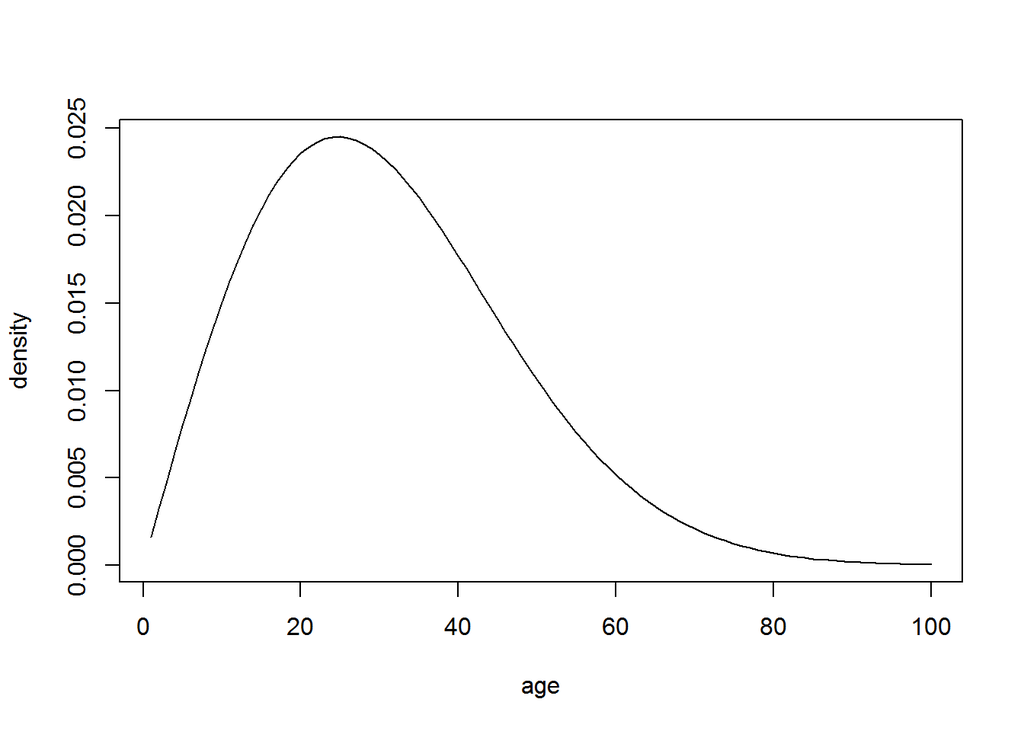

```r
age <- seq(1, 100, by=1)
age <- round(age, 1)
density <- dweibull(age, 2, 35)
plot(age, density, type="l")
```

Here is a probability density function that might represent the survival probability for an individual. It is simple from a mathematical perspective, but may not reflect actual survival probabilities for a realistic individual.

In a density function, probabilities are computed by measuring the area under the curve. So the probability that you will die as a young adult (between ages 20 and 30) is

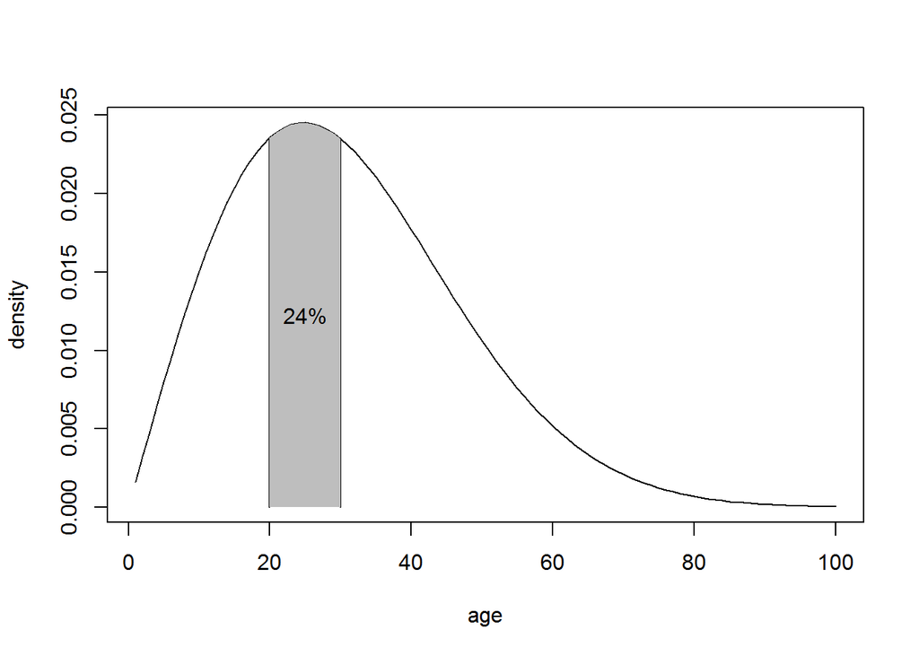

```r
pct <- function(x) (paste(round(100*x), "%", sep=""))
plot(age, density, type="l")
age1 <- 20
age2 <- 30
age_mean <- (age1+age2) / 2
segments(age1, 0, age1, density[age==age1])
segments(age2, 0, age2, density[age==age2])
age_range <- (age>=age1) & (age<=age2)
polygon(x=c(age2, age1, age[age_range]), y=c(0, 0, density[age_range]), border=NA, col="gray")
p1 <- pweibull(age1, 2, 35)
p2 <- pweibull(age2, 2, 35)
probability <- p2 - p1
text(age_mean, 0.5*density[age==age_mean], pct(probability))
```

The probability that you will die as a middle aged adult (between ages 40 and 70) is

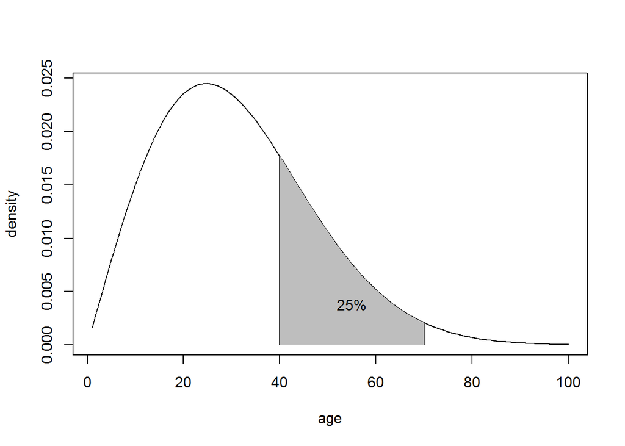

```r
plot(age, density, type="l")
age3 <- 40
age4 <- 70
age_mean <- (age3+age4) / 2
segments(age3, 0, age3, density[age==age3])
segments(age4, 0, age4, density[age==age4])
age_range <- (age>=age3) & (age<=age4)
polygon(x=c(age4, age3, age[age_range]), y=c(0, 0, density[age_range]), border=NA, col="gray")
p3 <- pweibull(age3, 2, 35)
p4 <- pweibull(age4, 2, 35)
probability <- p4 - p3
text(age_mean, 0.5*density[age==age_mean], pct(probability))
```

Now these are interesting probabilities, but they are not directly comparable for two reasons.

1. The probabilities are over different time frames.
2. The probabilities should be adjusted to account for the smaller number of survivors at the older ages.

To fix the first problem, you need to look at the rate of death. This is the number of deaths per million people divided by the number of days in the time interval. The choice of a million people instead of, say 10 thousand, and the choice of days instead of say, months or years, is a bit arbitrary. But as long as you are consistent, the comparisons are fairer.

If you have 10,000 people, you’d see 2418 funerals between the ages of 20 and 30 and since there are 3652 days in this interval, you’d have a rate of 0.66 (2418 / 3652) funerals per day. But of ten thousand people, there would be 2786 who died before age 20 and 7214 survivors. So the rate among 10,000 people alive at age 20 is 0.91 (0.66*10000 / 7214) funerals per day.

Middle aged adults (40-70) have about the same probability, but it’s over a longer period of time. Counterbalancing this, there are not quite as many people who survive to 40. Here’s the math.

The hazard rate is defined in a similar way.

h(t) = (P[t $\le$ T $\le$ T+$\Delta$t] / $\Delta$t) / P[T $\ge$ t]

where $\Delta$t is very small.

It’s a rate since it involves a measure of time, so the hazard rate does not necessarily have to be bounded between 0 and 1 like a probability would be.

The hazard rate is mathematically equivalent to the density function divided by the survival function. You need some basic calculus to establish this

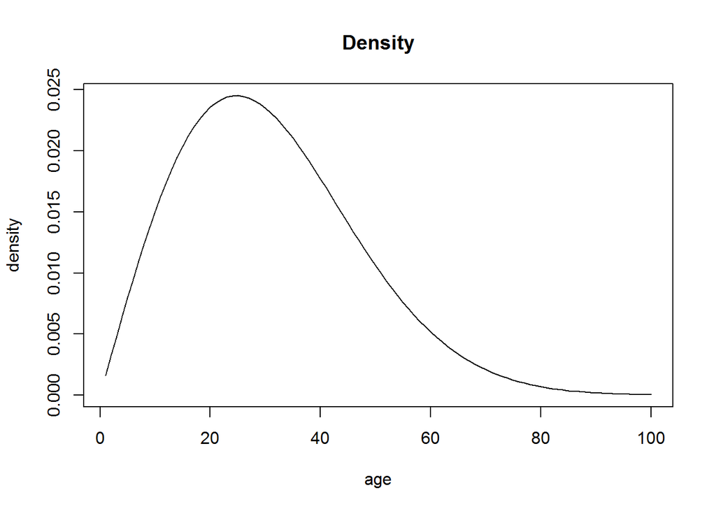

```r
plot(age, density, type="l")
title("Density")
```

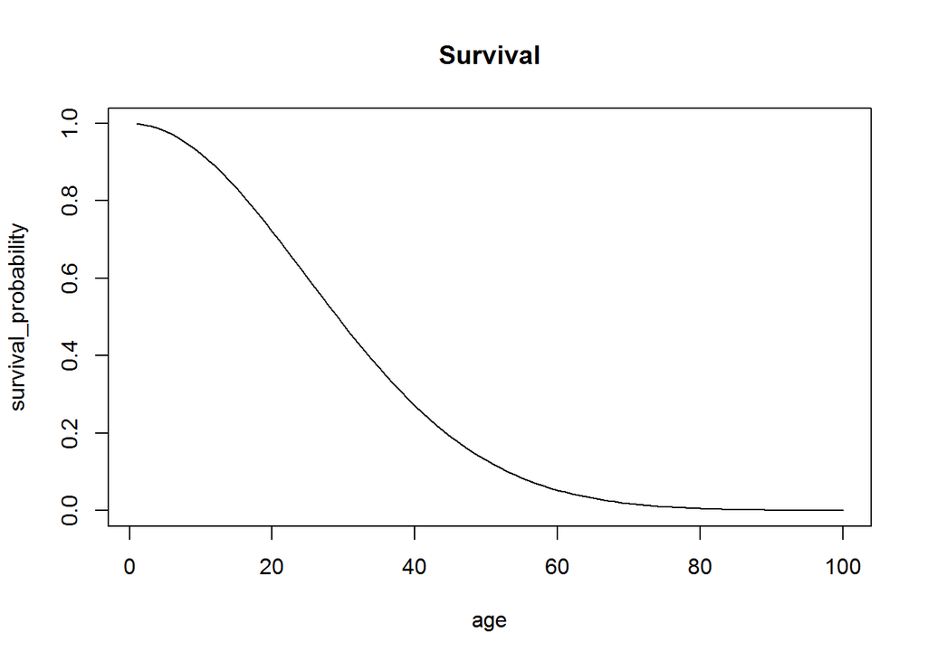

```r
survival_probability <- 1 - pweibull(age, 2, 35)
plot(age, survival_probability, type="l")
title("Survival")
```

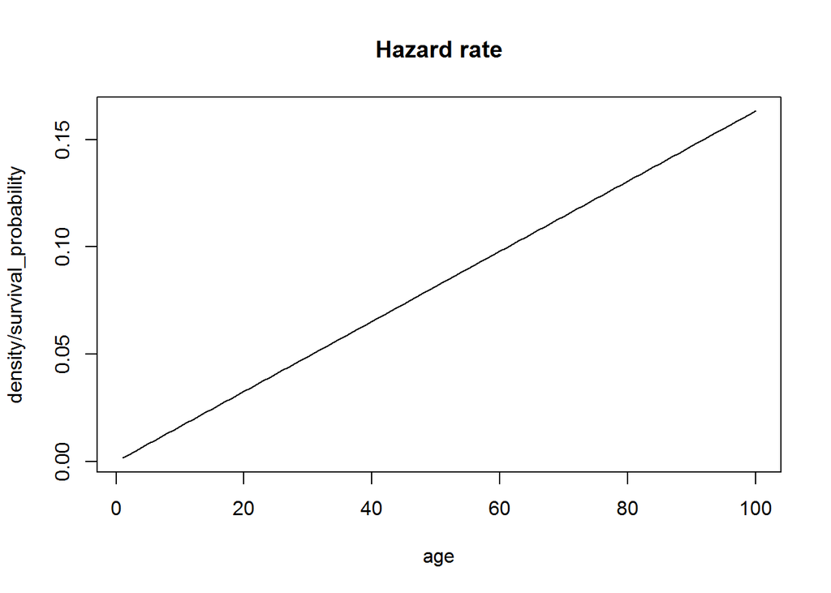

```r
plot(age, density / survival_probability, type="l")
title("Hazard rate")
```

This is an example of an increasing hazard rate. Your death rate is low at any particular time point, but the rate increases over time. People who talk about survival with respect to machines refer to this as “new better than used.”

There are examples of a decreasing hazard rate or “used better than new.”

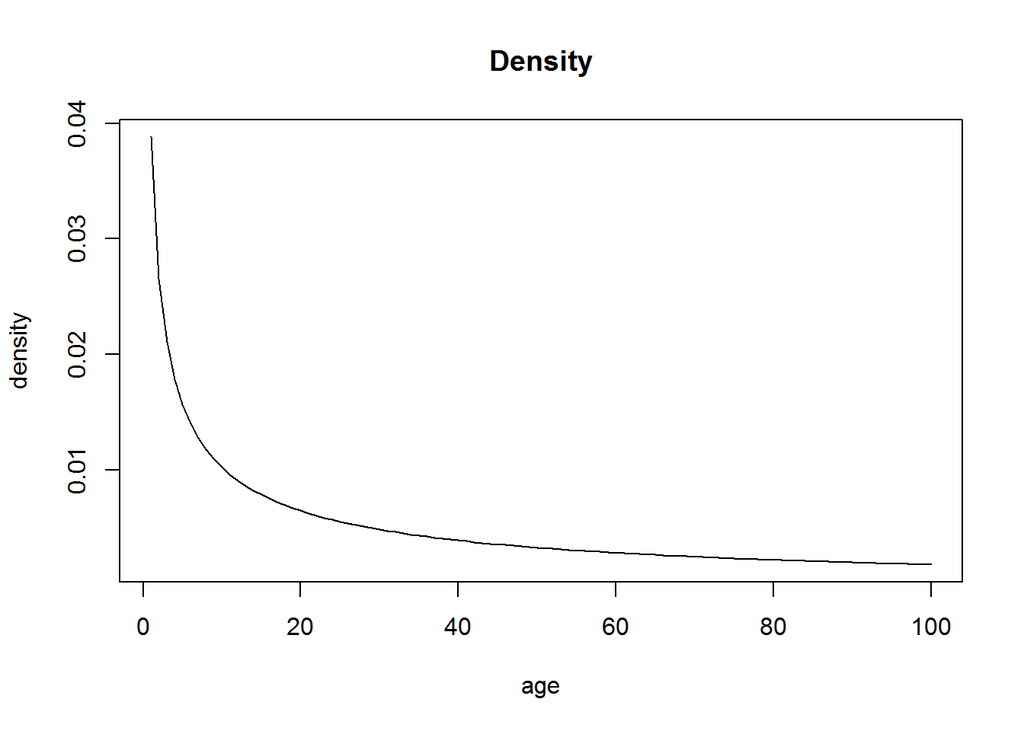

```r
density <- dweibull(age, 0.5, 140)
plot(age, density, type="l")
title("Density")
```

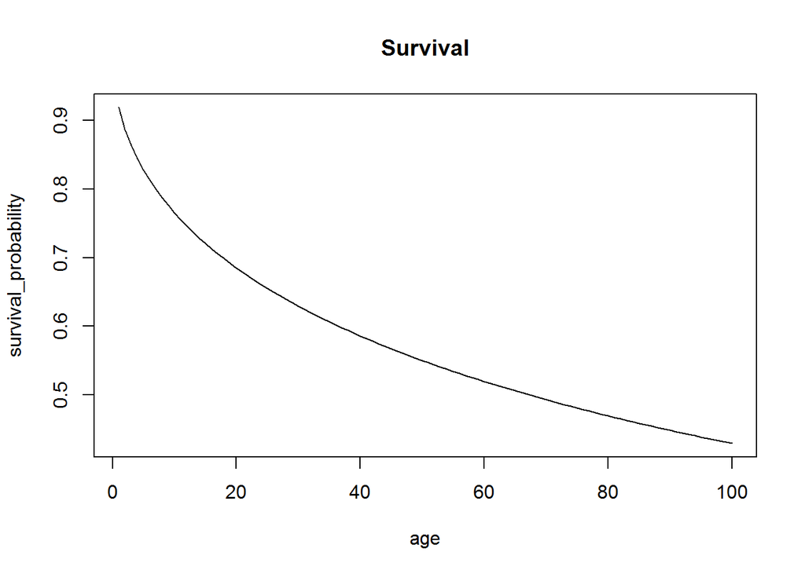

```r
survival_probability <- 1 - pweibull(age, 0.5, 140)
plot(age, survival_probability, type="l")
title("Survival")
```

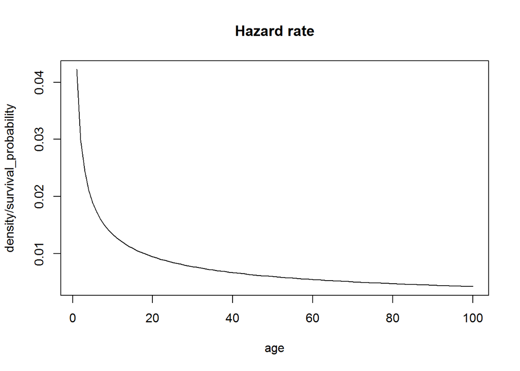

```r
plot(age, density / survival_probability, type="l")
title("Hazard rate")
```

This is reminiscent of the Nietzsche quote “That which does not kill us makes us stronger.” This does not mean that you’ll never die, but your short term risk of dying is greatest when you are young and small. From the engineering perspective if a machine has a decreasing haard rate, that means that it gets battle hardened as it get older and becomes more reliable over time.

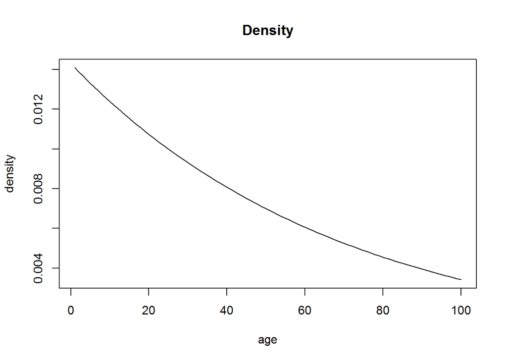

```r
density <- dexp(age, rate=1/70)
plot(age, density, type="l")
title("Density")
```

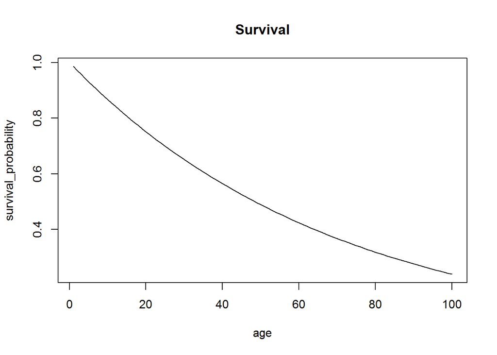

```r
survival_probability <- 1 - pexp(age, rate=1/70)
plot(age, survival_probability, type="l")
title("Survival")
```

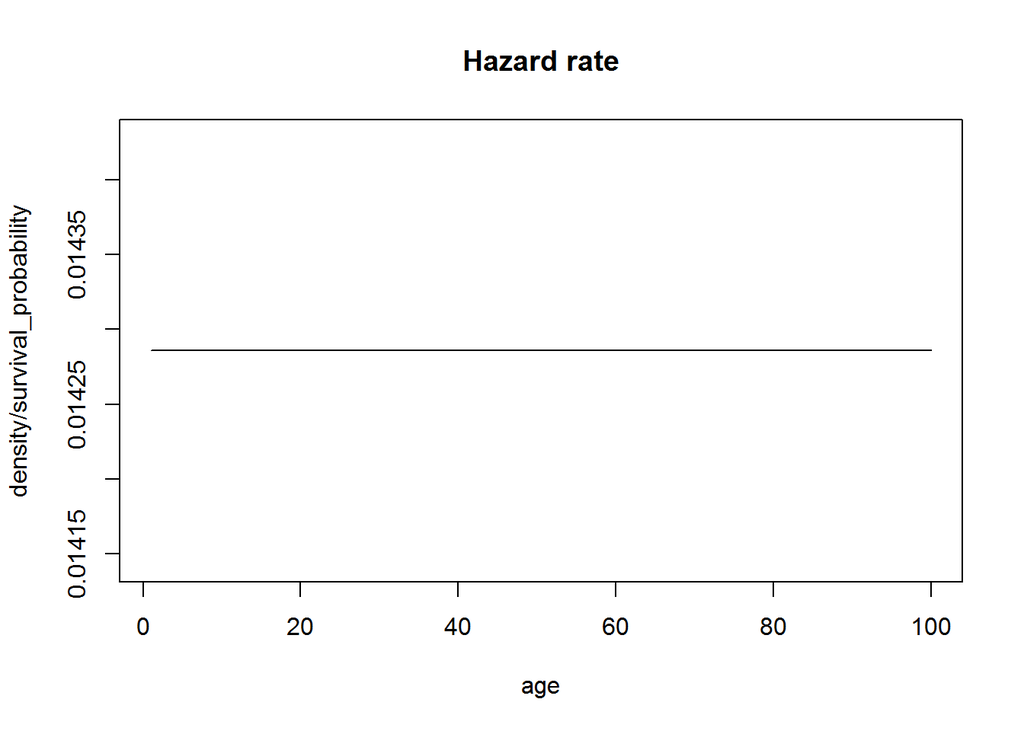

```r
plot(age, density / survival_probability, type="l")
title("Hazard rate")
```

The exponential distribution is said to have a “memoryless” property. What this means is that the short term risk of death is unrelated to age. In other words a new machine performs no better or no worse than a used machine.

Another common pattern for the hazard rate is called the bathtub hazard. This is a hazard that starts out high early, decreases, flattens out for a while and then gradually increases later in life. The bathtub hazard is the one that most closely resembles the human experience.

You can find a nice illustration of the bathtub hazrd at

https://commons.wikimedia.org/wiki/File:Bathtub_curve.svg

## Why is the hazard function important?

1. Knowledge of the hazard function for an industrial product can help you decide on how and when to employ preventive maintenance.
2. It can also help you extrapolate survival patterns beyond the range of observed values, such as for long-term reliability testing.
3. If you are planning a new research study, the hazard function can help you decide how many patients to study and the length of follow-up for these patients.
4. Assumptions about the hazard function are critical for regression models of survival.

## The heroin data set.

On the Australian Data and Story Library website, you can find a data set on the amount of time that a patient spens in a rehabilitation clinic. You can read a description of the data at

–> http://www.statsci.org/data/oz/heroin.html

and the tab delimited data is at

–> http://www.statsci.org/data/oz/heroin.txt

```r
me_raw <- read.table("heroin.txt", header=TRUE)
head(me_raw)
```

```
##   ID Clinic Status Time Prison. Dose ID.1 Clinic.1 Status.1 Time.1
## 1  1      1      1  428       0   50  132        2        0    633
## 2  2      1      1  275       1   55  133        2        1    661
## 3  3      1      1  262       0   55  134        2        1    232
## 4  4      1      1  183       0   30  135        2        1     13
## 5  5      1      1  259       1   65  137        2        0    563
## 6  6      1      1  714       0   55  138        2        0    969
##   Prison..1 Dose.1
## 1         0     70
## 2         0     40
## 3         1     70
## 4         1     60
## 5         0     70
## 6         0     80
```

```r
m1 <- me_raw[ , 1:6]
m2 <- me_raw[ , 7:12]
names(m2) <- names(m1)
me <- rbind(m1, m2)
head(me)
```

```
##   ID Clinic Status Time Prison. Dose
## 1  1      1      1  428       0   50
## 2  2      1      1  275       1   55
## 3  3      1      1  262       0   55
## 4  4      1      1  183       0   30
## 5  5      1      1  259       1   65
## 6  6      1      1  714       0   55
```

```r
tail(me)
```

```
##      ID Clinic Status Time Prison. Dose
## 233 260      1      1   59       1   45
## 234 261      1      1   33       1   60
## 235 262      2      1  540       0   80
## 236 263      2      0  551       0   65
## 237 264      1      1   90       0   40
## 238 266      1      1   47       0   45
```

```r
dim(me)
```

```
## [1] 238   6
```

```r
summary(me$Time)
```

```
##    Min. 1st Qu.  Median    Mean 3rd Qu.    Max.
##     2.0   171.2   367.5   402.6   585.5  1076.0
```

```r
summary(me$Dose)
```

```
##    Min. 1st Qu.  Median    Mean 3rd Qu.    Max.
##    20.0    50.0    60.0    60.4    70.0   110.0
```

```r
table(me$Dose)
```

```
##
##  20  30  35  40  45  50  55  60  65  70  75  80  90 100 110
##   1   2   2  30  10  27  21  52  22  24   6  35   2   3   1
```

```r
table(me$Clinic)
```

```
##
##   1   2
## 163  75
```

```r
table(me$Status)
```

```
##
##   0   1
##  88 150
```

```r
table(me$Prison.)
```

```
##
##   0   1
## 127 111
```

In R, the default is that 0 represents a censored value and 1 represents an event.

Before you fit a Cox proportional hazards model, you should look at the Kaplan-Meier curve and the logrank test.

```r
library("survival")
su <- Surv(me$Time, me$Status)
print(su)
```

```
##   [1]  428   275   262   183   259   714   438   796+  892   393   161+
##  [12]  836   523   612   212   399   771   514   512   624   209   341
##  [23]  299   826+  262   566+  368   302   602+  652   293   564+  394
##  [34]  755   591   787+  739   550   837   612   581+  523   504   785
##  [45]  774   560   160   482   518   683   147   563   646   899   857
##  [56]  180   452   760   496   258   181   386   439+  563+  337   613+
##  [67]  192   405+  667   905+  247   821   821   517+  346+  294   244
##  [78]   95   376   212    96   532   522   679   408+  840+  148+  168
##  [89]  489   541+  205   475+  237   517   749   150   465   708   713+
## [100]  146+  450   555+  460    53+  122    35   532+  684+  769+  591+
## [111]  769+  609+  932+  932+  587+   26    72+  641+  367+  633+  661
## [122]  232    13   563+  969+ 1052+  944+  881+  190    79   884+  170
## [133]  286   358+  326+  769+  161   564+  268   611+  322  1076+    2+
## [144]  788+  575+  109   730+  790+  456+  231   143    86+ 1021+  684+
## [155]  878   216   808+  268   222+  683+  496+  389   126    17   350
## [166]  531+  317+  461+   37   167   358    49   457   127     7    29
## [177]   62   150+  223   129+  204+  129   581   176    30    41   543+
## [188]  210+  193   434   367   348    28+  337+  175+  149   546    84
## [199]  283+  533   207   216    28+   67    62+  111+  257   136   342+
## [210]   41   531+   98+  145    50    53+  103+    2+  157    75    19
## [221]   35   394+  117   175   180   314   480+  325+  280   204   366
## [232]  531+   59    33   540   551+   90    47
```

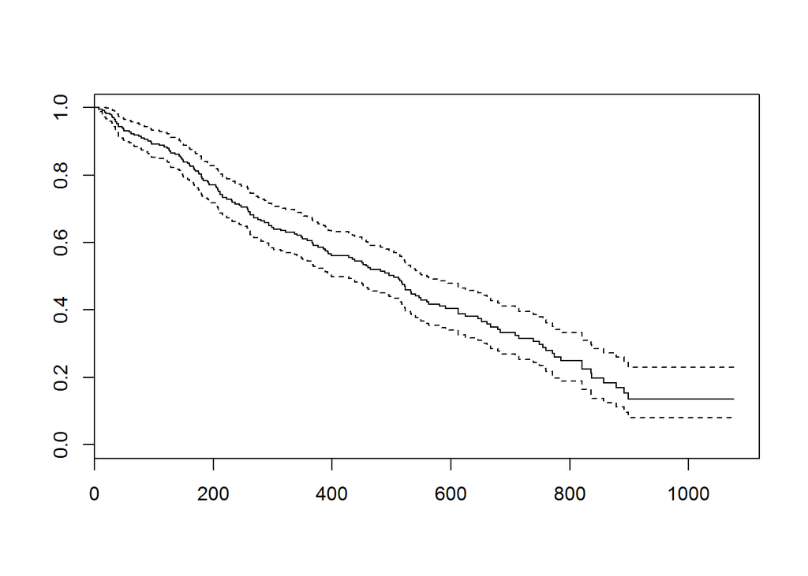

```r
plot(survfit(su~1))
```

```r
quantile(survfit(su~1))
```

```
## $quantile
##  25  50  75
## 212 504 821
##
## $lower
##  25  50  75
## 180 399 739
##
## $upper
##  25  50  75
## 262 560 892
```

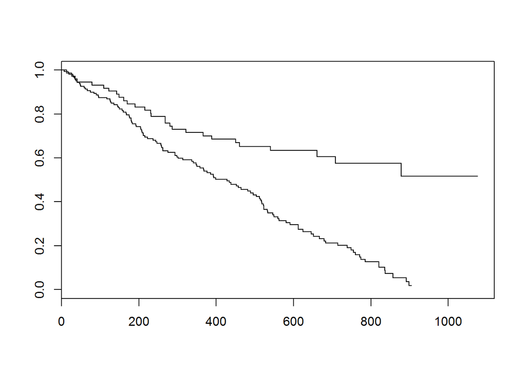

```r
plot(survfit(su~me$Clinic))
```

```r
quantile(survfit(su~me$Clinic))
```

```
## $quantile
##              25  50  75
## me$Clinic=1 192 428 652
## me$Clinic=2 280  NA  NA
##
## $lower
##              25  50  75
## me$Clinic=1 167 348 563
## me$Clinic=2 190 661  NA
##
## $upper
##              25  50  75
## me$Clinic=1 247 514 760
## me$Clinic=2 661  NA  NA
```

```r
survdiff(su~me$Clinic)
```

```
## Call:
## survdiff(formula = su ~ me$Clinic)
##
##               N Observed Expected (O-E)^2/E (O-E)^2/V
## me$Clinic=1 163      122     90.9      10.6      27.9
## me$Clinic=2  75       28     59.1      16.4      27.9
##
##  Chisq= 27.9  on 1 degrees of freedom, p= 1.28e-07
```

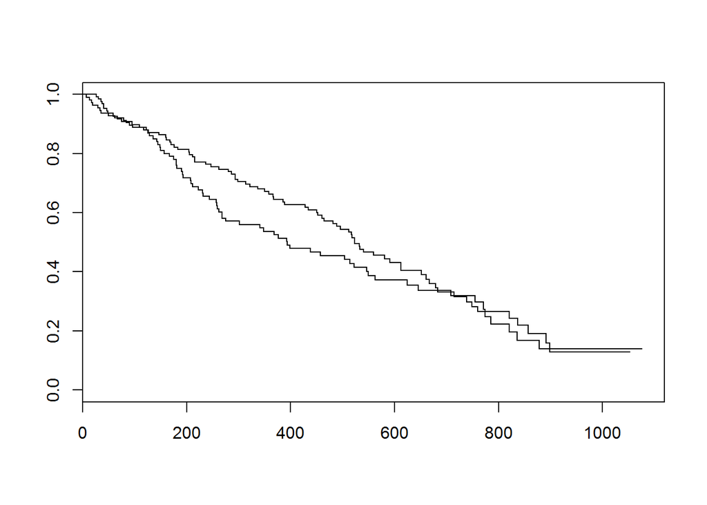

```r
plot(survfit(su~me$Prison.))
```

```r
quantile(survfit(su~me$Prison.))
```

```
## $quantile
##               25  50  75
## me$Prison.=0 262 523 821
## me$Prison.=1 181 394 774
##
## $lower
##               25  50  75
## me$Prison.=0 183 460 683
## me$Prison.=1 150 268 646
##
## $upper
##               25  50 75
## me$Prison.=0 366 652 NA
## me$Prison.=1 244 563 NA
```

```r
survdiff(su~me$Prison.)
```

```
## Call:
## survdiff(formula = su ~ me$Prison.)
##
##                N Observed Expected (O-E)^2/E (O-E)^2/V
## me$Prison.=0 127       81     87.8     0.519      1.26
## me$Prison.=1 111       69     62.2     0.732      1.26
##
##  Chisq= 1.3  on 1 degrees of freedom, p= 0.262
```

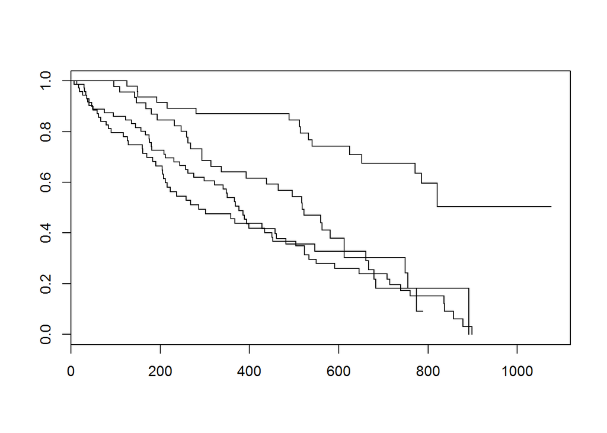

```r
dose_quartiles <- cut(me$Dose, c(0, 50, 60, 70, 999))
plot(survfit(su~dose_quartiles))
```

```r
quantile(survfit(su~dose_quartiles))
```

```
## $quantile
##                          25  50  75
## dose_quartiles=(0,50]   129 286 679
## dose_quartiles=(50,60]  180 376 646
## dose_quartiles=(60,70]  268 518 749
## dose_quartiles=(70,999] 540  NA  NA
##
## $lower
##                          25  50  75
## dose_quartiles=(0,50]    79 212 546
## dose_quartiles=(50,60]  136 299 504
## dose_quartiles=(60,70]  193 393 612
## dose_quartiles=(70,999] 489 771  NA
##
## $upper
##                          25  50  75
## dose_quartiles=(0,50]   207 546  NA
## dose_quartiles=(50,60]  275 504 837
## dose_quartiles=(60,70]  465 749  NA
## dose_quartiles=(70,999] 821  NA  NA
```

```r
survdiff(su~dose_quartiles)
```

```
## Call:
## survdiff(formula = su ~ dose_quartiles)
##
##                          N Observed Expected (O-E)^2/E (O-E)^2/V
## dose_quartiles=(0,50]   72       45     30.9    6.4011    8.2141
## dose_quartiles=(50,60]  73       57     40.0    7.1994    9.9032
## dose_quartiles=(60,70]  46       31     30.1    0.0276    0.0353
## dose_quartiles=(70,999] 47       17     49.0   20.8595   33.3789
##
##  Chisq= 36.8  on 3 degrees of freedom, p= 5.16e-08
```

Here’s how you calculate the log rank test

```r
library("tibble")
tb <- table(me$Time[me$Status==1], me$Prison.[me$Status==1])
tim <- as.numeric(dimnames(tb)[[1]])
o1j <- tb[, 1]
o2j <- tb[, 2]
oj <- o1j+o2j
n1j <- rep(NA, length(tim))
n2j <- rep(NA, length(tim))
for (j in 1:length(tim)) {
  n1j[j] <- sum(me$Time[me$Prison.==0]>=tim[j])
  n2j[j] <- sum(me$Time[me$Prison.==1]>=tim[j])
}
nj <- n1j+n2j
pj <- round(n1j/nj, 2)
e1j <- round(oj*pj, 2)
v1j <- round(oj*pj*(1-pj) * (nj-oj)/(nj-1), 2)
tail(tibble(tim, o1j, o2j, oj, n1j, n2j, nj, pj, e1j, v1j))
```

```
## # A tibble: 6 x 10
##     tim   o1j   o2j    oj   n1j   n2j    nj    pj   e1j   v1j
##   <dbl> <int> <int> <int> <int> <int> <int> <dbl> <dbl> <dbl>
## 1   836     0     1     1    10     7    17  0.59  0.59  0.24
## 2   837     1     0     1    10     6    16  0.62  0.62  0.24
## 3   857     1     0     1     8     6    14  0.57  0.57  0.25
## 4   878     0     1     1     7     6    13  0.54  0.54  0.25
## 5   892     1     0     1     6     4    10  0.60  0.60  0.24
## 6   899     1     0     1     5     4     9  0.56  0.56  0.25
```

```r
logrank_z <- sum(o1j-e1j) / sqrt(sum(v1j))
logrank_x2 <- logrank_z^2
```

The Cox proportional hazards model allows a lot more flexibility than the logrank test. You can include a continuous predictor variable (no need to create quartiles for dose) and multiple predictors (allowing for a risk adjusted model, for example).

```r
coxph(su~me$Prison.)
```

```
## Call:
## coxph(formula = su ~ me$Prison.)
##
##             coef exp(coef) se(coef)    z    p
## me$Prison. 0.184     1.202    0.164 1.12 0.26
##
## Likelihood ratio test=1.25  on 1 df, p=0.264
## n= 238, number of events= 150
```

```r
coxph(su~dose_quartiles)
```

```
## Call:
## coxph(formula = su ~ dose_quartiles)
##
##                           coef exp(coef) se(coef)     z       p
## dose_quartiles(50,60]  -0.0412    0.9597   0.2004 -0.21    0.84
## dose_quartiles(60,70]  -0.3409    0.7111   0.2346 -1.45    0.15
## dose_quartiles(70,999] -1.5304    0.2164   0.2928 -5.23 1.7e-07
##
## Likelihood ratio test=42.5  on 3 df, p=3.19e-09
## n= 238, number of events= 150
```

```r
coxph(su~me$Dose)
```

```
## Call:
## coxph(formula = su ~ me$Dose)
##
##             coef exp(coef) se(coef)     z       p
## me$Dose -0.03590   0.96473  0.00598 -6.01 1.9e-09
##
## Likelihood ratio test=36.9  on 1 df, p=1.25e-09
## n= 238, number of events= 150
```

```r
coxph(su~strata(me$Clinic)+me$Prison.+me$Dose)
```

```
## Call:
## coxph(formula = su ~ strata(me$Clinic) + me$Prison. + me$Dose)
##
##                coef exp(coef) se(coef)     z       p
## me$Prison.  0.38960   1.47640  0.16893  2.31   0.021
## me$Dose    -0.03511   0.96549  0.00646 -5.43 5.6e-08
##
## Likelihood ratio test=33.9  on 2 df, p=4.32e-08
## n= 238, number of events= 150
```

Save everything for later re-use

```r
save.image("illustrate_hazard.RData")
```